# act_report

## Report: act_report

- Create a **250-word-minimum written report** called "act_report.pdf" or "act_report.html" that communicates the insights and displays the visualization(s) produced from your wrangled data. This is to be framed as an external document, like a blog post or magazine article, for example.

## Analyzing and Visualizing Data

In this section, we analyzed and visualized the weratedogs account

The insights discovered were as follows:

1. pupper is the commonest dog stage
2. iPhone is the most used device by twitter users who engaged weratedogs account
3. Charlie and Lucy are quite popular dog names

How did we arrive at those? Let's go one at a time

### INSIGHT 1: Charlie and Lucy are quite popular dog names

- After melting and merging, we sorted the dog_name column and arranged them in decreasing order of frequency.

**Top 5 Dog Names From The WeRateDogs Dataset:**

```
- Charlie       44
- Lucy          44
- Oliver        40
- Cooper        40
- Penny         36
```

**The Plots:**

```
- Histogram : Details of count wasn't so clear
```

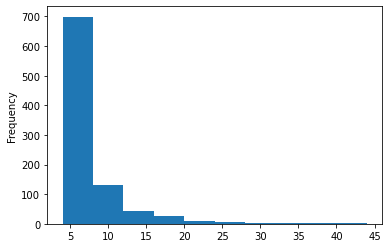

```
- Bar Plot : Axis showing the dog names wasn't readable neither was the plot wide enough to fit the 939 unique names cleaned for this analysis
```

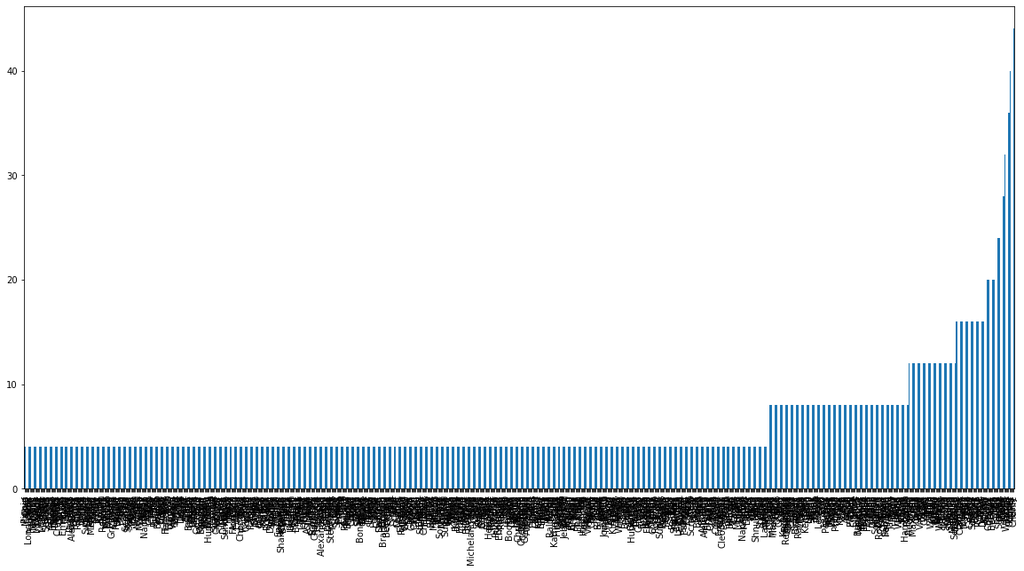

```
- Line Plot : This at least shows the leading name clearly
```

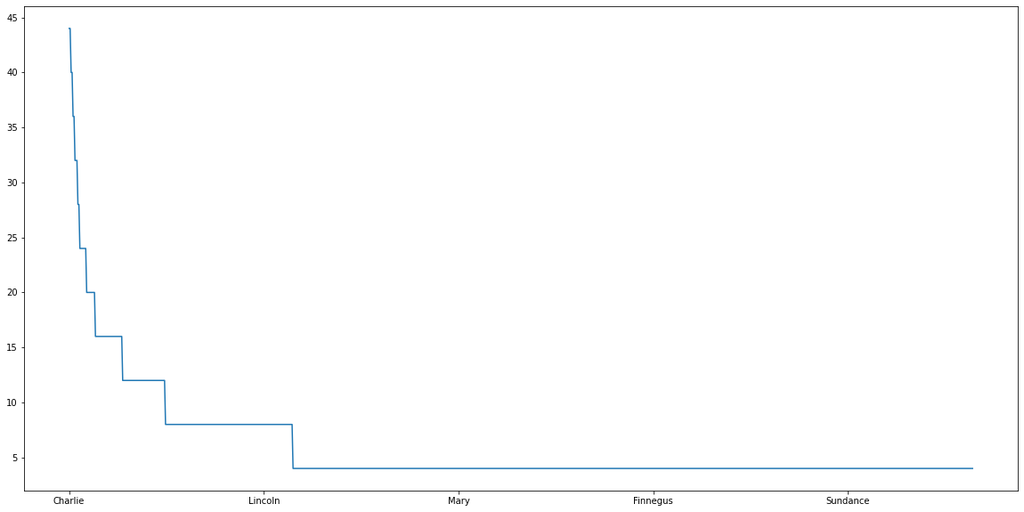

### INSIGHT 2: iPhone is the most used device by twitter users who engaged weratedogs account

- A simple bar plot of the 'source' column after melting and merging, and sorted in increasing order of frequency, gave us all the info needed to know the most used tweet_source but first, we had previewed it from a frequency counter function called value_count() that counts number of occurences of a unique entry.

**Brief description of the source column:**

```
- Number of rows:                         8388
- Unique tweet sources:                      4
- Most common source:       Twitter for iPhone
```

**A count of users per tweet source (after melting and merging):**

```
- Twitter for iPhone    7856
- Vine                   364
- Twitter Web Client     124
- TweetDeck               44
```

**The Plot:**

```
- A Plot showing The Most Used Means Of Tweeting At The WeRateDogs Handle
```

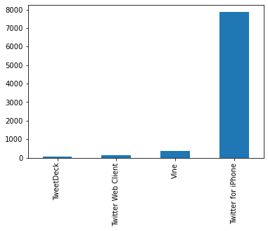

### INSIGHT 3: Pupper is the commonest dog stage:

- A similar method to counting the tweet_source was employed

**Brief description of the dog_stage column:**

```
- Number of rows:                 347
- Unique dog stages:                4
- Most common dog stage:       pupper
```

**A count of dogs per dog stage (after melting and merging):**

```
- pupper     230
- doggo       83
- puppo       24
- floofer     10
```

**The Plot:**

```
- Plotting To See The More Common Dog Stages
```

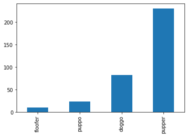

### Further Relevant Insights

**Other Visualizations include:**

```
- A Scatterplot of Twitter Likes and their Retweets
```

[figure not shown]

```
- Plotting The Correlation Between Favorite Count & Retweet Count Of WeRateDogs
```

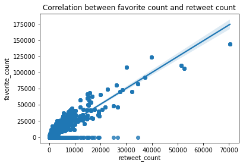

```
- Plotting The Retweet Count Over Time
```

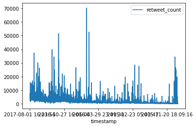

```
- Plotting The Favorite Count Over Time
```

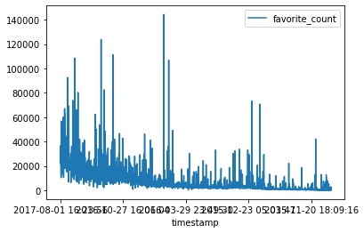